# Modelos de regressão para desfecho escalar e preditores funcionais - soluções para problema da medicina obstétrica

# Variáveis funcionais após imputação dos dados

### Dados:

```r
dados <- read_excel("dados_igs_completas_5avals.xlsx")

medida_colo_long <- dados[,c("id","igp_parto","ig_aval_sem","medida_colo_imp")]

medida_colo_wide <- pivot_wider(
  medida_colo_long,
  names_from = ig_aval_sem,
  values_from = medida_colo_imp
  )

num_contra_long <- dados[,c("id","igp_parto","ig_aval_sem","num_contra_imp")]

num_contra_wide <- pivot_wider(
  num_contra_long,
  names_from = ig_aval_sem,
  values_from = num_contra_imp
  )

# Labels para gráficos:
axis_labels <- c("sem24_26","sem27_28","sem29_30","sem31_32","sem33_34")
axis_labels <- as.factor(axis_labels)
```

## Perfis

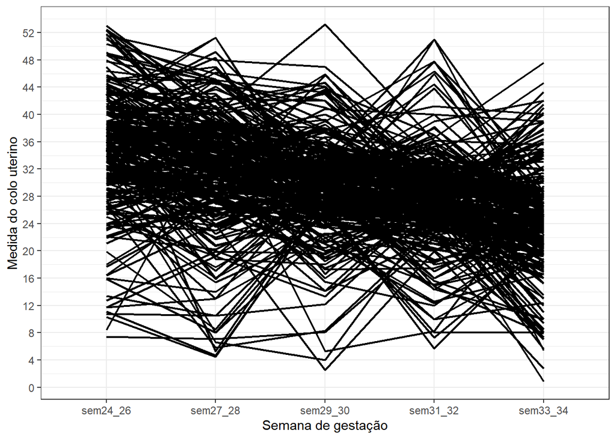

```r
#Cervical measurements:
perfil_mcolo <-
  ggplot(medida_colo_long,
         aes(x=ig_aval_sem,y=medida_colo_imp)) +
  geom_line(aes(group=id),size=0.8) +
  labs(y="Medida do colo uterino", x="Semana de gestação") +
  scale_y_continuous(breaks=seq(0,54,4)) +
  theme_bw()

perfil_mcolo
```

**Figura 22**: Gráfico de perfil para medida do colo após imputação dos dados.

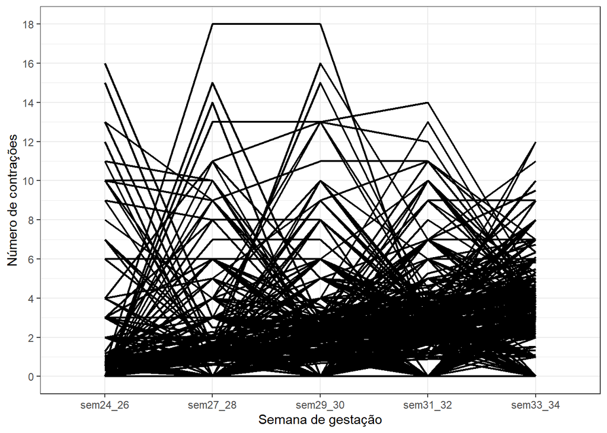

```r
#Contraction measurements:
perfil_ncontra <-
  ggplot(num_contra_long,
         aes(x=ig_aval_sem,y=num_contra_imp)) +
  geom_line(aes(group=id),size=0.8) +
  labs(y="Número de contrações", x="Semana de gestação") +
  scale_y_continuous(breaks=seq(0,20,2)) +
  theme_bw()

perfil_ncontra
```

**Figura 23**: Gráfico de perfil para o número de contrações após imputação dos dados.

## Funções média e desvio padrão

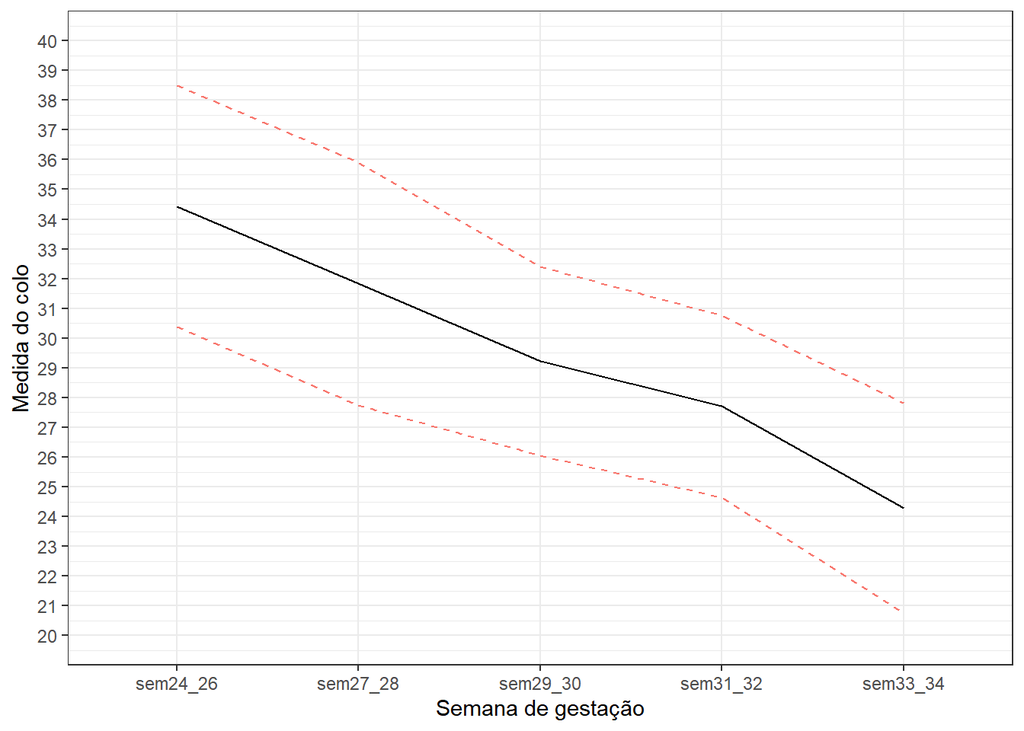

```r
require(fda)

#Mean of cervical measurements and 1/2 +- deviation:
avaliacoes <- 1:5
rng <- c(1,5)
knots <- avaliacoes
norder <- 2 #5 bases.
nbasis <- length(knots)+norder-2
m_colo_basis <- create.bspline.basis(rng,nbasis,
                                     norder,knots)
lambdac <- df2lambda(avaliacoes,m_colo_basis)
colofdPar <- fdPar(m_colo_basis,lambda=lambdac)
colo_transpose <- t(medida_colo_wide[,3:7])
colofd <- smooth.basis(avaliacoes,
                       colo_transpose,colofdPar)$fd

colo_mean <- mean.fd(colofd)
colo_sd <- sd.fd(colofd)

x1 = colo_mean+(1/2)*colo_sd
x2 = colo_mean-(1/2)*colo_sd

df <- data.frame(
  x = axis_labels,
  mean = predict(colo_mean, newdata = axis_labels),
  desvio_mais = predict(x1, newdata = axis_labels),
  desvio_menos = predict(x2, newdata = axis_labels)
)

ggplot(data=df) +
  geom_line(aes(x=x, y=mean, group = 1)) +
  geom_line(aes(x=x, y=mean.1, group = 1, colour = "red"), linetype = "dashed") +
  geom_line(aes(x=x, y=mean.2, group = 1, colour = "red"), linetype = "dashed") +
  labs(x="Semana de gestação", y="Medida do colo") +
  scale_y_continuous(breaks = 20:40, limits = c(20,40)) +
  theme_bw() +
  theme(legend.position="none")
```

**Figura 24**: Gráfico da função média para medida do colo (curva preta) e desvio padrão de +- 1/2 (curva vermelha).

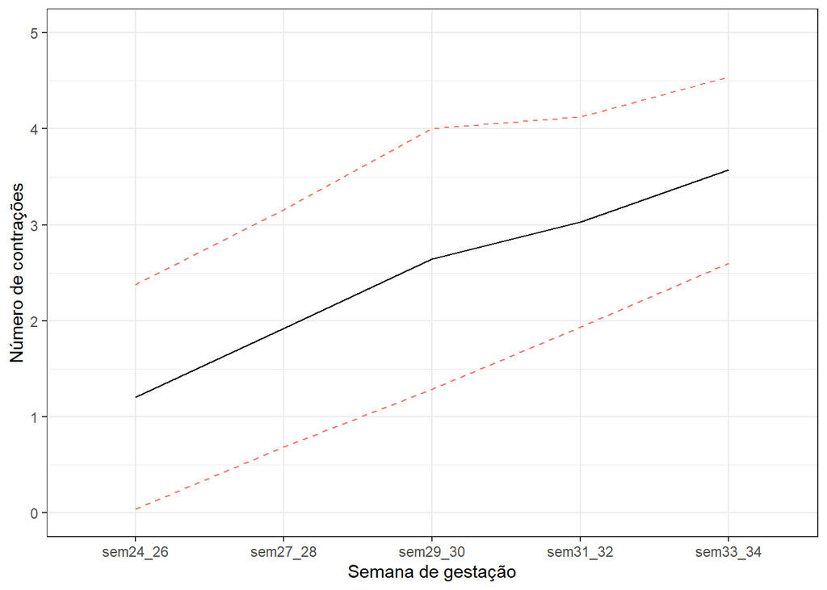

```r
#Mean of contraction measurements and 1/2 +- deviation:
avaliacoes <- 1:5
rng <- c(1,5)
knots <- avaliacoes
norder <- 2 #5 bases.
nbasis <- length(knots)+norder-2
n_contra_basis <- create.bspline.basis(rng,nbasis,
                                       norder,knots)
lambdac <- df2lambda(avaliacoes,n_contra_basis)
contrafdPar <- fdPar(n_contra_basis,lambda=lambdac)
contra_transpose <- t(num_contra_wide[,3:7])
contrafd <- smooth.basis(avaliacoes,
                         contra_transpose,
                         contrafdPar)$fd

contra_mean <- mean.fd(contrafd)
contra_sd <- sd.fd(contrafd)

x1 = contra_mean+(1/2)*contra_sd
x2 = contra_mean-(1/2)*contra_sd

df <- data.frame(
  x = axis_labels,
  mean = predict(contra_mean, newdata = axis_labels),
  desvio_mais = predict(x1, newdata = axis_labels),
  desvio_menos = predict(x2, newdata = axis_labels)
)

ggplot(data=df) +
  geom_line(aes(x=x, y=mean, group = 1)) +
  geom_line(aes(x=x, y=mean.1, group = 1, colour = "red"), linetype = "dashed") +
  geom_line(aes(x=x, y=mean.2, group = 1, colour = "red"), linetype = "dashed") +
  labs(x="Semana de gestação", y="Número de contrações") +
  scale_y_continuous(breaks = 0:5, limits = c(0,5)) +
  theme_bw() +
  theme(legend.position="none")
```

**Figura 25**: Gráfico da função média para o número de contrações (curva preta) e desvio padrão de +- 1/2 (curva vermelha).

# Ajustes

## 1 covariável funcional (refund)

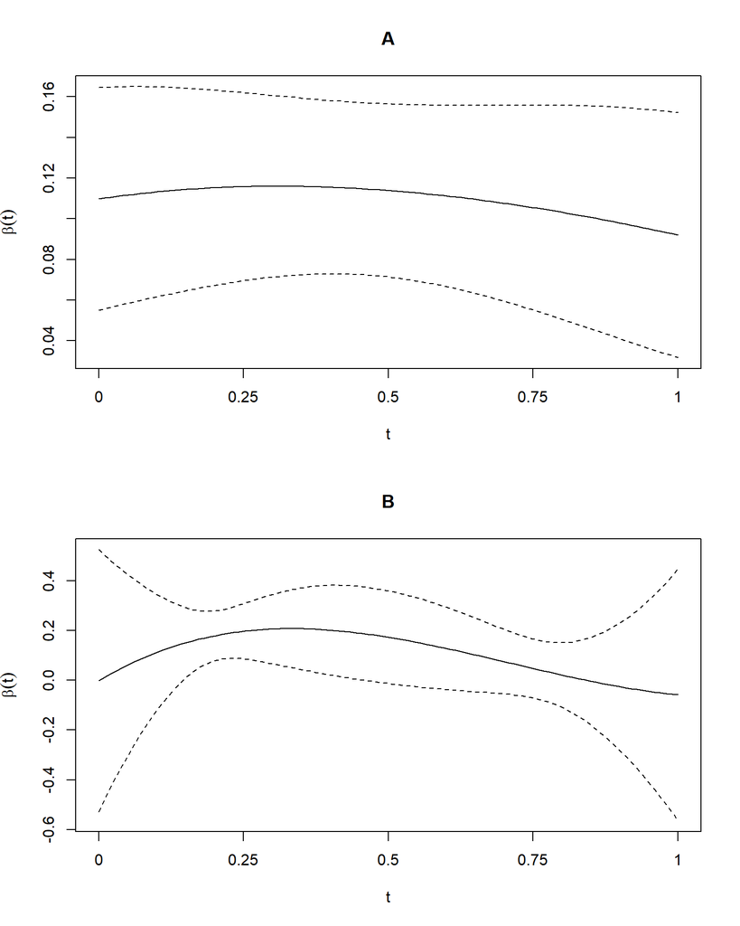

```r
require(refund)

##Cervical measurements:
Y <- medida_colo_wide$igp_parto
X <- medida_colo_wide[,3:7]
X <- as.matrix(X)

#fpc() - Functional principal component regression:
fitJJ_1 = pfr(Y ~ fpc(X, k = 4))

#lf() -  Regression splines:
fitJJ_2 = pfr(Y ~ lf(X, bs = "ps", k = 4, fx = T))

par(mfrow = c(2,1))

fpc_plot <- plot(
  fitJJ_1,
  main = "A",
  ylab= expression(paste(beta(t))),
  xlab= "t",
  xlim = c(0,1),
  xaxt = "n",
  cex.lab= 1,
  cex.axis= 1
)
axis(side = 1, at = seq(0,1,0.25), lty = 1, labels = seq(0,1,0.25))

lf_plot <- plot(
  fitJJ_2,
  main = "B",
  ylab= expression(paste(beta(t))),
  xlab= "t",
  xlim = c(0,1),
  xaxt = "n",
  cex.lab= 1,
  cex.axis= 1
)
axis(side = 1, at = seq(0,1,0.25), lty = 1, labels = seq(0,1,0.25))
```

**Figura 26A**: Função $\beta(t)$ da medida do colo, estimada por regressão funcional penalizada com abordagem de componentes principais (orientada à dados).

**Figura 26B**: Função $\beta(t)$ da medida do colo, estimada por regressão funcional penalizada com abordagem do modelo linear funcional utilizando P-splines.

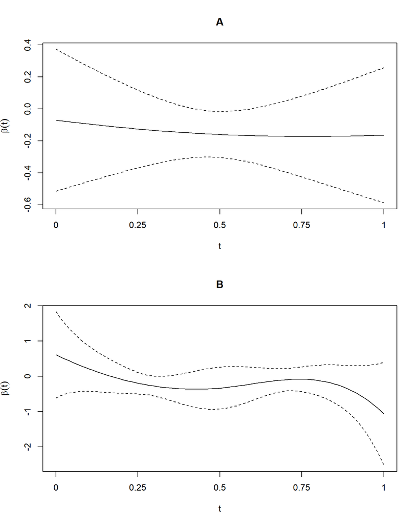

```r
##Contraction measurements:
Y <- num_contra_wide$igp_parto
X <- num_contra_wide[,3:7]
X <- as.matrix(X)

#fpc() - functional principal component regression:
fitJJ_1 = pfr(Y ~ fpc(X, k = 5))

#lf() -  Regression splines:
fitJJ_2 = pfr(Y ~ lf(X, bs = "ps", k = 5, fx = T))

par(mfrow = c(2,1))

fpc_plot <- plot(
  fitJJ_1,
  main = "A",
  ylab= expression(paste(beta(t))),
  xlab= "t",
  xlim = c(0,1),
  xaxt = "n",
  cex.lab= 1,
  cex.axis= 1
)
axis(side = 1, at = seq(0,1,0.25), lty = 1, labels = seq(0,1,0.25))

lf_plot <- plot(
  fitJJ_2,
  main = "B",
  ylab= expression(paste(beta(t))),
  xlab= "t",
  xlim = c(0,1),
  xaxt = "n",
  cex.lab= 1,
  cex.axis= 1
)
axis(side = 1, at = seq(0,1,0.25), lty = 1, labels = seq(0,1,0.25))
```

**Figura 27A**: Função $\beta(t)$ do número de contrações, estimada por regressão funcional penalizada com abordagem de componentes principais (orientada à dados).

**Figura 27B**: Função $\beta(t)$ do número de contrações, estimada por regressão funcional penalizada com abordagem do modelo linear funcional utilizando P-splines.

## 2 covariáveis funcionais

Devido a falta de informação quanto a aplicação de métodos de regressão com mais de 1 covariável funcional, esta seção ainda está em estudo. Além disso, há informações de que o pacote *refund* permite o uso de 2 covariáveis funcionais, mas não há informação de como se aplica, portanto tenho tentado entrar em contato com os mantedores do pacote e explorado diferentes possíveis formas de aplicar, porém ainda sem sucesso.

# Amostra treino e teste (imputação de dados antiga)

Com o objetivo de verificar as melhores opções dos argumentos dos modelos funcionais, e de comparar os modelos funcionais e modelos simples (modelos que fazem uso de uma medida resumo), os dados foram separados em duas amostras, sendo uma amostra treino que contém $70\%$ dos dados, para a qual foi construído os modelos, e uma amostra de testes contendo $30\%$ dos dados, para a qual foi feito predições.

Os resultados abaixo mostram o critério de informação de Akaike (AIC) calculados nos modelos construídos na amostra treino, e o erro quadrático médio (EQM) que utiliza as predições obtidas da amostra teste.

## Resultados para medida do colo

### PFR com abordagem por regressão funcional linear (LF):

Tabela de AIC dos modelos funcionais (abordagem por regressão funcional penalizada)

|  | ps fx = T | ps fx = F | tp fx = T | tp fx = F | cr fx = T | cr fx = F |
| --- | --- | --- | --- | --- | --- | --- |
| k = 3 | NA | NA | 717.14 | 716.89 | 717.10 | 716.88 |
| k = 4 | 719.24 | 716.88 | 719.13 | 716.61 | 719.14 | 716.65 |
| k = 5 | 720.97 | 716.93 | 720.97 | 716.62 | 720.97 | 716.62 |

Nota: Descrição dos termos  
<sup>1</sup> ps = P-splines; <sup>2</sup> tp = thin plate splines; <sup>3</sup> cr = cubic spline; <sup>4</sup> fx = (TRUE = sem penalização); <sup>5</sup> k = dimensão da base; <sup>6</sup> NA = não rodou para o k especificado;

Tabela do EQM dos modelos funcionais (abordagem por regressão funcional penalizada)

|  | ps fx = T | ps fx = F | tp fx = T | tp fx = F | cr fx = T | cr fx = F |
| --- | --- | --- | --- | --- | --- | --- |
| k = 3 | NA | NA | 2.55 | 2.50 | 2.56 | 2.50 |
| k = 4 | 2.54 | 2.49 | 2.55 | 2.48 | 2.55 | 2.48 |
| k = 5 | 2.57 | 2.49 | 2.57 | 2.48 | 2.57 | 2.48 |

Nota: Descrição dos termos  
<sup>1</sup> ps = P-splines; <sup>2</sup> tp = thin plate splines; <sup>3</sup> cr = cubic spline; <sup>4</sup> fx = (TRUE = sem penalização); <sup>5</sup> k = dimensão da base; <sup>6</sup> NA = não rodou para o k especificado;

Tabela do EQM dos modelos simples (fazem uso de medida resumo)

|  | EQM |
| --- | --- |
| Modelo com a média das avaliações | 2.40 |
| Modelo com a ultima avaliação | 2.44 |

### PFR com abordagem por componentes principais (FPC):

Em andamento…

## Resultados para o número de contrações

### PFR com abordagem por regressão funcional linear (LF):

Tabela de AIC dos modelos funcionais (abordagem por regressão funcional penalizada)

|  | ps fx = T | ps fx = F | tp fx = T | tp fx = F | cr fx = T | cr fx = F |
| --- | --- | --- | --- | --- | --- | --- |
| k = 3 | NA | NA | 736.78 | 735.1 | 736.79 | 735.10 |
| k = 4 | 737.79 | 735.10 | 737.77 | 735.1 | 737.77 | 735.10 |
| k = 5 | 739.74 | 735.09 | 739.74 | 735.1 | 739.74 | 735.09 |

Nota: Descrição dos termos  
<sup>1</sup> ps = P-splines; <sup>2</sup> tp = thin plate splines; <sup>3</sup> cr = cubic spline; <sup>4</sup> fx = (TRUE = sem penalização); <sup>5</sup> k = dimensão da base; <sup>6</sup> NA = não rodou para o k especificado;

Tabela do EQM dos modelos funcionais (abordagem por regressão funcional penalizada)

|  | ps fx = T | ps fx = F | tp fx = T | tp fx = F | cr fx = T | cr fx = F |
| --- | --- | --- | --- | --- | --- | --- |
| k = 3 | NA | NA | 2.68 | 2.66 | 2.68 | 2.66 |
| k = 4 | 2.63 | 2.66 | 2.63 | 2.66 | 2.63 | 2.66 |
| k = 5 | 2.62 | 2.66 | 2.62 | 2.66 | 2.62 | 2.66 |

Nota: Descrição dos termos  
<sup>1</sup> ps = P-splines; <sup>2</sup> tp = thin plate splines; <sup>3</sup> cr = cubic spline; <sup>4</sup> fx = (TRUE = sem penalização); <sup>5</sup> k = dimensão da base; <sup>6</sup> NA = não rodou para o k especificado;

Tabela do EQM dos modelos simples (fazem uso de medida resumo)

|  | EQM |
| --- | --- |
| Modelo com a média das avaliações | 2.61 |
| Modelo com a ultima avaliação | 2.49 |

### PFR com abordagem por componentes principais (FPC):

Em andamento…

# Amostra treino e teste (imputação de dados recente)

## Resultados para medida do colo

### Tabelas AIC dos métodos lf e fpc (variável resposta sem transformação):

#### Utilizando a imputação por trajetória spline _imp:

Tabela de AIC dos modelos funcionais por lf()

|  | ps fx = T | tp fx = T | cr fx = T |
| --- | --- | --- | --- |
| k = 3 | NA | 714.10 | 714.10 |
| k = 4 | 716.05 | 716.05 | 716.05 |
| k = 5 | 717.97 | 717.97 | 717.97 |

Nota: Descrição dos termos  
<sup>1</sup> ps = P-splines; <sup>2</sup> tp = thin plate splines; <sup>3</sup> cr = cubic spline; <sup>4</sup> fx = (TRUE = sem penalização); <sup>5</sup> k = dimensão da base; <sup>6</sup> NA = não rodou para o k especificado;

Tabela de AIC dos modelos funcionais por fpc()

|  | ps fx = T | tp fx = T | cr fx = T |
| --- | --- | --- | --- |
| k = 3 | NA | NA | NA |
| k = 4 | 712.15 | NA | NA |
| k = 5 | 714.10 | NA | NA |

Nota: Descrição dos termos  
<sup>1</sup> ps = P-splines; <sup>2</sup> tp = thin plate splines; <sup>3</sup> cr = cubic spline; <sup>4</sup> fx = (TRUE = sem penalização); <sup>5</sup> k = dimensão da base; <sup>6</sup> NA = não rodou para o k ou fx especificado;

#### Utilizando a imputação por regressão _compl (considerando todas as covariáveis fixas significativas):

Tabela de AIC dos modelos funcionais por lf()

|  | ps fx = T | tp fx = T | cr fx = T |
| --- | --- | --- | --- |
| k = 3 | NA | 717.14 | 717.10 |
| k = 4 | 719.23 | 719.13 | 719.13 |
| k = 5 | 720.97 | 720.97 | 720.97 |

Nota: Descrição dos termos  
<sup>1</sup> ps = P-splines; <sup>2</sup> tp = thin plate splines; <sup>3</sup> cr = cubic spline; <sup>4</sup> fx = (TRUE = sem penalização); <sup>5</sup> k = dimensão da base; <sup>6</sup> NA = não rodou para o k especificado;

Tabela de AIC dos modelos funcionais por fpc()

|  | ps fx = T | tp fx = T | cr fx = T |
| --- | --- | --- | --- |
| k = 3 | NA | NA | NA |
| k = 4 | 716.53 | NA | NA |
| k = 5 | 716.99 | NA | NA |

Nota: Descrição dos termos  
<sup>1</sup> ps = P-splines; <sup>2</sup> tp = thin plate splines; <sup>3</sup> cr = cubic spline; <sup>4</sup> fx = (TRUE = sem penalização); <sup>5</sup> k = dimensão da base; <sup>6</sup> NA = não rodou para o k ou fx especificado;

#### Utilizando a imputação por regressão _compl_soIG (considerando apenas a idade gestacional de avaliação):

Tabela de AIC dos modelos funcionais por lf()

|  | ps fx = T | tp fx = T | cr fx = T |
| --- | --- | --- | --- |
| k = 3 | NA | 719.10 | 719.08 |
| k = 4 | 720.98 | 720.94 | 720.94 |
| k = 5 | 722.70 | 722.70 | 722.70 |

Nota: Descrição dos termos  
<sup>1</sup> ps = P-splines; <sup>2</sup> tp = thin plate splines; <sup>3</sup> cr = cubic spline; <sup>4</sup> fx = (TRUE = sem penalização); <sup>5</sup> k = dimensão da base; <sup>6</sup> NA = não rodou para o k especificado;

Tabela de AIC dos modelos funcionais por fpc()

|  | ps fx = T | tp fx = T | cr fx = T |
| --- | --- | --- | --- |
| k = 3 | NA | NA | NA |
| k = 4 | 717.39 | NA | NA |
| k = 5 | 719.28 | NA | NA |

Nota: Descrição dos termos  
<sup>1</sup> ps = P-splines; <sup>2</sup> tp = thin plate splines; <sup>3</sup> cr = cubic spline; <sup>4</sup> fx = (TRUE = sem penalização); <sup>5</sup> k = dimensão da base; <sup>6</sup> NA = não rodou para o k ou fx especificado;

### Tabelas AIC dos métodos lf e fpc (variável resposta transformada):

#### Utilizando a imputação por trajetória spline _imp:

Tabela de AIC dos modelos funcionais por lf()

|  | ps fx = T | tp fx = T | cr fx = T |
| --- | --- | --- | --- |
| k = 3 | NA | 257.25 | 257.26 |
| k = 4 | 259.24 | 259.25 | 259.25 |
| k = 5 | 260.90 | 260.90 | 260.90 |

Nota: Descrição dos termos  
<sup>1</sup> ps = P-splines; <sup>2</sup> tp = thin plate splines; <sup>3</sup> cr = cubic spline; <sup>4</sup> fx = (TRUE = sem penalização); <sup>5</sup> k = dimensão da base; <sup>6</sup> NA = não rodou para o k especificado;

Tabela de AIC dos modelos funcionais por fpc()

|  | ps fx = T | tp fx = T | cr fx = T |
| --- | --- | --- | --- |
| k = 3 | NA | NA | NA |
| k = 4 | 255.94 | NA | NA |
| k = 5 | 257.28 | NA | NA |

Nota: Descrição dos termos  
<sup>1</sup> ps = P-splines; <sup>2</sup> tp = thin plate splines; <sup>3</sup> cr = cubic spline; <sup>4</sup> fx = (TRUE = sem penalização); <sup>5</sup> k = dimensão da base; <sup>6</sup> NA = não rodou para o k ou fx especificado;

#### Utilizando a imputação por regressão _compl (considerando todas as covariáveis fixas significativas):

Tabela de AIC dos modelos funcionais por lf()

|  | ps fx = T | tp fx = T | cr fx = T |
| --- | --- | --- | --- |
| k = 3 | NA | 261.81 | 261.71 |
| k = 4 | 263.79 | 263.59 | 263.60 |
| k = 5 | 264.32 | 264.32 | 264.32 |

Nota: Descrição dos termos  
<sup>1</sup> ps = P-splines; <sup>2</sup> tp = thin plate splines; <sup>3</sup> cr = cubic spline; <sup>4</sup> fx = (TRUE = sem penalização); <sup>5</sup> k = dimensão da base; <sup>6</sup> NA = não rodou para o k especificado;

Tabela de AIC dos modelos funcionais por fpc()

|  | ps fx = T | tp fx = T | cr fx = T |
| --- | --- | --- | --- |
| k = 3 | NA | NA | NA |
| k = 4 | 260.50 | NA | NA |
| k = 5 | 261.19 | NA | NA |

Nota: Descrição dos termos  
<sup>1</sup> ps = P-splines; <sup>2</sup> tp = thin plate splines; <sup>3</sup> cr = cubic spline; <sup>4</sup> fx = (TRUE = sem penalização); <sup>5</sup> k = dimensão da base; <sup>6</sup> NA = não rodou para o k ou fx especificado;

#### Utilizando a imputação por regressão _compl_soIG (considerando apenas a idade gestacional de avaliação):

Tabela de AIC dos modelos funcionais por lf()

|  | ps fx = T | tp fx = T | cr fx = T |
| --- | --- | --- | --- |
| k = 3 | NA | 263.95 | 263.93 |
| k = 4 | 265.96 | 265.95 | 265.95 |
| k = 5 | 266.50 | 266.50 | 266.50 |

Nota: Descrição dos termos  
<sup>1</sup> ps = P-splines; <sup>2</sup> tp = thin plate splines; <sup>3</sup> cr = cubic spline; <sup>4</sup> fx = (TRUE = sem penalização); <sup>5</sup> k = dimensão da base; <sup>6</sup> NA = não rodou para o k especificado;

Tabela de AIC dos modelos funcionais por fpc()

|  | ps fx = T | tp fx = T | cr fx = T |
| --- | --- | --- | --- |
| k = 3 | NA | NA | NA |
| k = 4 | 261.98 | NA | NA |
| k = 5 | 263.87 | NA | NA |

Nota: Descrição dos termos  
<sup>1</sup> ps = P-splines; <sup>2</sup> tp = thin plate splines; <sup>3</sup> cr = cubic spline; <sup>4</sup> fx = (TRUE = sem penalização); <sup>5</sup> k = dimensão da base; <sup>6</sup> NA = não rodou para o k ou fx especificado;

### Tabelas de EQM dos modelos com método lf e dos modelos lineares simples (variável resposta sem transformação)

#### Utilizando a imputação por trajetória spline _imp:

Tabela do EQM dos modelos funcionais por lf()

|  | ps fx = T | tp fx = T | cr fx = T |
| --- | --- | --- | --- |
| k = 3 | NA | 2.16 | 2.16 |
| k = 4 | 2.16 | 2.16 | 2.16 |
| k = 5 | 2.14 | 2.14 | 2.14 |

Nota: Descrição dos termos  
<sup>1</sup> ps = P-splines; <sup>2</sup> tp = thin plate splines; <sup>3</sup> cr = cubic spline; <sup>4</sup> fx = (TRUE = sem penalização); <sup>5</sup> k = dimensão da base; <sup>6</sup> NA = não rodou para o k especificado;

Tabela do EQM dos modelos simples (fazem uso de medida resumo)

|  | EQM |
| --- | --- |
| Modelo com a média das avaliações | 2.15 |
| Modelo com a ultima avaliação | 2.21 |

#### Utilizando a imputação por regressão _compl (considerando todas as covariáveis fixas significativas):

Tabela do EQM dos modelos funcionais por lf()

|  | ps fx = T | tp fx = T | cr fx = T |
| --- | --- | --- | --- |
| k = 3 | NA | 2.55 | 2.55 |
| k = 4 | 2.53 | 2.54 | 2.54 |
| k = 5 | 2.57 | 2.57 | 2.57 |

Nota: Descrição dos termos  
<sup>1</sup> ps = P-splines; <sup>2</sup> tp = thin plate splines; <sup>3</sup> cr = cubic spline; <sup>4</sup> fx = (TRUE = sem penalização); <sup>5</sup> k = dimensão da base; <sup>6</sup> NA = não rodou para o k especificado;

Tabela do EQM dos modelos simples (fazem uso de medida resumo)

|  | EQM |
| --- | --- |
| Modelo com a média das avaliações | 2.40 |
| Modelo com a ultima avaliação | 2.44 |

#### Utilizando a imputação por regressão _compl_soIG (considerando apenas a idade gestacional de avaliação):

Tabela do EQM dos modelos funcionais por lf()

|  | ps fx = T | tp fx = T | cr fx = T |
| --- | --- | --- | --- |
| k = 3 | NA | 2.51 | 2.51 |
| k = 4 | 2.52 | 2.52 | 2.52 |
| k = 5 | 2.56 | 2.56 | 2.56 |

Nota: Descrição dos termos  
<sup>1</sup> ps = P-splines; <sup>2</sup> tp = thin plate splines; <sup>3</sup> cr = cubic spline; <sup>4</sup> fx = (TRUE = sem penalização); <sup>5</sup> k = dimensão da base; <sup>6</sup> NA = não rodou para o k especificado;

Tabela do EQM dos modelos simples (fazem uso de medida resumo)

|  | EQM |
| --- | --- |
| Modelo com a média das avaliações | 2.45 |
| Modelo com a ultima avaliação | 2.50 |

### Tabelas de EQM dos modelos com método lf e dos modelos lineares simples (variável resposta transformada)

#### Utilizando a imputação por trajetória spline _imp:

Tabela do EQM dos modelos funcionais por lf()

|  | ps fx = T | tp fx = T | cr fx = T |
| --- | --- | --- | --- |
| k = 3 | NA | 0.227 | 0.228 |
| k = 4 | 0.228 | 0.228 | 0.228 |
| k = 5 | 0.226 | 0.226 | 0.226 |

Nota: Descrição dos termos  
<sup>1</sup> ps = P-splines; <sup>2</sup> tp = thin plate splines; <sup>3</sup> cr = cubic spline; <sup>4</sup> fx = (TRUE = sem penalização); <sup>5</sup> k = dimensão da base; <sup>6</sup> NA = não rodou para o k especificado;

Tabela do EQM dos modelos simples (fazem uso de medida resumo)

|  | EQM |
| --- | --- |
| Modelo com a média das avaliações | 0.224 |
| Modelo com a ultima avaliação | 0.228 |

#### Utilizando a imputação por regressão _compl (considerando todas as covariáveis fixas significativas):

Tabela do EQM dos modelos funcionais por lf()

|  | ps fx = T | tp fx = T | cr fx = T |
| --- | --- | --- | --- |
| k = 3 | NA | 0.248 | 0.249 |
| k = 4 | 0.246 | 0.247 | 0.247 |
| k = 5 | 0.253 | 0.253 | 0.253 |

Nota: Descrição dos termos  
<sup>1</sup> ps = P-splines; <sup>2</sup> tp = thin plate splines; <sup>3</sup> cr = cubic spline; <sup>4</sup> fx = (TRUE = sem penalização); <sup>5</sup> k = dimensão da base; <sup>6</sup> NA = não rodou para o k especificado;

Tabela do EQM dos modelos simples (fazem uso de medida resumo)

|  | EQM |
| --- | --- |
| Modelo com a média das avaliações | 0.242 |
| Modelo com a ultima avaliação | 0.247 |

#### Utilizando a imputação por regressão _compl_soIG (considerando apenas a idade gestacional de avaliação):

Tabela do EQM dos modelos funcionais por lf()

|  | ps fx = T | tp fx = T | cr fx = T |
| --- | --- | --- | --- |
| k = 3 | NA | 0.246 | 0.246 |
| k = 4 | 0.246 | 0.246 | 0.246 |
| k = 5 | 0.252 | 0.252 | 0.252 |

Nota: Descrição dos termos  
<sup>1</sup> ps = P-splines; <sup>2</sup> tp = thin plate splines; <sup>3</sup> cr = cubic spline; <sup>4</sup> fx = (TRUE = sem penalização); <sup>5</sup> k = dimensão da base; <sup>6</sup> NA = não rodou para o k especificado;

Tabela do EQM dos modelos simples (fazem uso de medida resumo)

|  | EQM |
| --- | --- |
| Modelo com a média das avaliações | 0.244 |
| Modelo com a ultima avaliação | 0.250 |

## Resultados para o número de contrações

### Tabelas AIC dos métodos lf e fpc (variável resposta sem transformação):

#### Utilizando a imputação por trajetória spline _imp:

Tabela de AIC dos modelos funcionais por lf()

|  | ps fx = T | tp fx = T | cr fx = T |
| --- | --- | --- | --- |
| k = 3 | NA | 738.08 | 738.08 |
| k = 4 | 739.83 | 739.84 | 739.84 |
| k = 5 | 741.74 | 741.74 | 741.74 |

Nota: Descrição dos termos  
<sup>1</sup> ps = P-splines; <sup>2</sup> tp = thin plate splines; <sup>3</sup> cr = cubic spline; <sup>4</sup> fx = (TRUE = sem penalização); <sup>5</sup> k = dimensão da base; <sup>6</sup> NA = não rodou para o k especificado;

Tabela de AIC dos modelos funcionais por fpc()

|  | ps fx = T | tp fx = T | cr fx = T |
| --- | --- | --- | --- |
| k = 3 | NA | NA | NA |
| k = 4 | 738.07 | NA | NA |
| k = 5 | 739.86 | NA | NA |

Nota: Descrição dos termos  
<sup>1</sup> ps = P-splines; <sup>2</sup> tp = thin plate splines; <sup>3</sup> cr = cubic spline; <sup>4</sup> fx = (TRUE = sem penalização); <sup>5</sup> k = dimensão da base; <sup>6</sup> NA = não rodou para o k ou fx especificado;

#### Utilizando a imputação por regressão _compl (considerando todas as covariáveis fixas significativas):

Tabela de AIC dos modelos funcionais por lf()

|  | ps fx = T | tp fx = T | cr fx = T |
| --- | --- | --- | --- |
| k = 3 | NA | 737.06 | 737.07 |
| k = 4 | 738.80 | 738.81 | 738.81 |
| k = 5 | 740.66 | 740.66 | 740.66 |

Nota: Descrição dos termos  
<sup>1</sup> ps = P-splines; <sup>2</sup> tp = thin plate splines; <sup>3</sup> cr = cubic spline; <sup>4</sup> fx = (TRUE = sem penalização); <sup>5</sup> k = dimensão da base; <sup>6</sup> NA = não rodou para o k especificado;

Tabela de AIC dos modelos funcionais por fpc()

|  | ps fx = T | tp fx = T | cr fx = T |
| --- | --- | --- | --- |
| k = 3 | NA | NA | NA |
| k = 4 | 737.06 | NA | NA |
| k = 5 | 738.84 | NA | NA |

Nota: Descrição dos termos  
<sup>1</sup> ps = P-splines; <sup>2</sup> tp = thin plate splines; <sup>3</sup> cr = cubic spline; <sup>4</sup> fx = (TRUE = sem penalização); <sup>5</sup> k = dimensão da base; <sup>6</sup> NA = não rodou para o k ou fx especificado;

#### Utilizando a imputação por regressão _compl_soIG (considerando apenas a idade gestacional de avaliação):

Tabela de AIC dos modelos funcionais por lf()

|  | ps fx = T | tp fx = T | cr fx = T |
| --- | --- | --- | --- |
| k = 3 | NA | 738.34 | 738.35 |
| k = 4 | 740.28 | 740.29 | 740.29 |
| k = 5 | 742.24 | 742.24 | 742.24 |

Nota: Descrição dos termos  
<sup>1</sup> ps = P-splines; <sup>2</sup> tp = thin plate splines; <sup>3</sup> cr = cubic spline; <sup>4</sup> fx = (TRUE = sem penalização); <sup>5</sup> k = dimensão da base; <sup>6</sup> NA = não rodou para o k especificado;

Tabela de AIC dos modelos funcionais por fpc()

|  | ps fx = T | tp fx = T | cr fx = T |
| --- | --- | --- | --- |
| k = 3 | NA | NA | NA |
| k = 4 | 738.33 | NA | NA |
| k = 5 | 740.33 | NA | NA |

Nota: Descrição dos termos  
<sup>1</sup> ps = P-splines; <sup>2</sup> tp = thin plate splines; <sup>3</sup> cr = cubic spline; <sup>4</sup> fx = (TRUE = sem penalização); <sup>5</sup> k = dimensão da base; <sup>6</sup> NA = não rodou para o k ou fx especificado;

### Tabelas AIC dos métodos lf e fpc (variável resposta transformada):

#### Utilizando a imputação por trajetória spline _imp:

Tabela de AIC dos modelos funcionais por lf()

|  | ps fx = T | tp fx = T | cr fx = T |
| --- | --- | --- | --- |
| k = 3 | NA | 275.38 | 275.39 |
| k = 4 | 277.16 | 277.17 | 277.17 |
| k = 5 | 279.03 | 279.03 | 279.03 |

Nota: Descrição dos termos  
<sup>1</sup> ps = P-splines; <sup>2</sup> tp = thin plate splines; <sup>3</sup> cr = cubic spline; <sup>4</sup> fx = (TRUE = sem penalização); <sup>5</sup> k = dimensão da base; <sup>6</sup> NA = não rodou para o k especificado;

Tabela de AIC dos modelos funcionais por fpc()

|  | ps fx = T | tp fx = T | cr fx = T |
| --- | --- | --- | --- |
| k = 3 | NA | NA | NA |
| k = 4 | 275.38 | NA | NA |
| k = 5 | 277.19 | NA | NA |

Nota: Descrição dos termos  
<sup>1</sup> ps = P-splines; <sup>2</sup> tp = thin plate splines; <sup>3</sup> cr = cubic spline; <sup>4</sup> fx = (TRUE = sem penalização); <sup>5</sup> k = dimensão da base; <sup>6</sup> NA = não rodou para o k ou fx especificado;

#### Utilizando a imputação por regressão _compl (considerando todas as covariáveis fixas significativas):

Tabela de AIC dos modelos funcionais por lf()

|  | ps fx = T | tp fx = T | cr fx = T |
| --- | --- | --- | --- |
| k = 3 | NA | 273.49 | 273.48 |
| k = 4 | 274.67 | 274.66 | 274.66 |
| k = 5 | 276.41 | 276.41 | 276.41 |

Nota: Descrição dos termos  
<sup>1</sup> ps = P-splines; <sup>2</sup> tp = thin plate splines; <sup>3</sup> cr = cubic spline; <sup>4</sup> fx = (TRUE = sem penalização); <sup>5</sup> k = dimensão da base; <sup>6</sup> NA = não rodou para o k especificado;

Tabela de AIC dos modelos funcionais por fpc()

|  | ps fx = T | tp fx = T | cr fx = T |
| --- | --- | --- | --- |
| k = 3 | NA | NA | NA |
| k = 4 | 273.55 | NA | NA |
| k = 5 | 274.63 | NA | NA |

Nota: Descrição dos termos  
<sup>1</sup> ps = P-splines; <sup>2</sup> tp = thin plate splines; <sup>3</sup> cr = cubic spline; <sup>4</sup> fx = (TRUE = sem penalização); <sup>5</sup> k = dimensão da base; <sup>6</sup> NA = não rodou para o k ou fx especificado;

#### Utilizando a imputação por regressão _compl_soIG (considerando apenas a idade gestacional de avaliação):

Tabela de AIC dos modelos funcionais por lf()

[output not shown]

Nota: Descrição dos termos  
<sup>1</sup> ps = P-splines; <sup>2</sup> tp = thin plate splines; <sup>3</sup> cr = cubic spline; <sup>4</sup> fx = (TRUE = sem penalização); <sup>5</sup> k = dimensão da base; <sup>6</sup> NA = não rodou para o k especificado;

Tabela de AIC dos modelos funcionais por fpc()

|  | ps fx = T | tp fx = T | cr fx = T |
| --- | --- | --- | --- |
| k = 3 | NA | NA | NA |
| k = 4 | 274.53 | NA | NA |
| k = 5 | 276.13 | NA | NA |

Nota: Descrição dos termos  
<sup>1</sup> ps = P-splines; <sup>2</sup> tp = thin plate splines; <sup>3</sup> cr = cubic spline; <sup>4</sup> fx = (TRUE = sem penalização); <sup>5</sup> k = dimensão da base; <sup>6</sup> NA = não rodou para o k ou fx especificado;

### Tabelas de EQM dos modelos com método lf e dos modelos lineares simples (variável resposta sem transformação)

#### Utilizando a imputação por trajetória spline _imp:

Tabela do EQM dos modelos funcionais por lf()

|  | ps fx = T | tp fx = T | cr fx = T |
| --- | --- | --- | --- |
| k = 3 | NA | 2.55 | 2.55 |
| k = 4 | 2.58 | 2.58 | 2.58 |
| k = 5 | 2.57 | 2.57 | 2.57 |

Nota: Descrição dos termos  
<sup>1</sup> ps = P-splines; <sup>2</sup> tp = thin plate splines; <sup>3</sup> cr = cubic spline; <sup>4</sup> fx = (TRUE = sem penalização); <sup>5</sup> k = dimensão da base; <sup>6</sup> NA = não rodou para o k especificado;

Tabela do EQM dos modelos simples (fazem uso de medida resumo)

|  | EQM |
| --- | --- |
| Modelo com a média das avaliações | 2.54 |
| Modelo com a ultima avaliação | 2.48 |

#### Utilizando a imputação por regressão _compl (considerando todas as covariáveis fixas significativas):

Tabela do EQM dos modelos funcionais por lf()

|  | ps fx = T | tp fx = T | cr fx = T |
| --- | --- | --- | --- |
| k = 3 | NA | 2.51 | 2.51 |
| k = 4 | 2.49 | 2.49 | 2.49 |
| k = 5 | 2.48 | 2.48 | 2.48 |

Nota: Descrição dos termos  
<sup>1</sup> ps = P-splines; <sup>2</sup> tp = thin plate splines; <sup>3</sup> cr = cubic spline; <sup>4</sup> fx = (TRUE = sem penalização); <sup>5</sup> k = dimensão da base; <sup>6</sup> NA = não rodou para o k especificado;

Tabela do EQM dos modelos simples (fazem uso de medida resumo)

|  | EQM |
| --- | --- |
| Modelo com a média das avaliações | 2.48 |
| Modelo com a ultima avaliação | 2.50 |

#### Utilizando a imputação por regressão _compl_soIG (considerando apenas a idade gestacional de avaliação):

Tabela do EQM dos modelos funcionais por lf()

|  | ps fx = T | tp fx = T | cr fx = T |
| --- | --- | --- | --- |
| k = 3 | NA | 2.54 | 2.54 |
| k = 4 | 2.54 | 2.54 | 2.54 |
| k = 5 | 2.53 | 2.53 | 2.53 |

Nota: Descrição dos termos  
<sup>1</sup> ps = P-splines; <sup>2</sup> tp = thin plate splines; <sup>3</sup> cr = cubic spline; <sup>4</sup> fx = (TRUE = sem penalização); <sup>5</sup> k = dimensão da base; <sup>6</sup> NA = não rodou para o k especificado;

Tabela do EQM dos modelos simples (fazem uso de medida resumo)

|  | EQM |
| --- | --- |
| Modelo com a média das avaliações | 2.53 |
| Modelo com a ultima avaliação | 2.55 |

### Tabelas de EQM dos modelos com método lf e dos modelos lineares simples (variável resposta transformada)

#### Utilizando a imputação por trajetória spline _imp:

Tabela do EQM dos modelos funcionais por lf()

|  | ps fx = T | tp fx = T | cr fx = T |
| --- | --- | --- | --- |
| k = 3 | NA | 0.260 | 0.260 |
| k = 4 | 0.263 | 0.263 | 0.263 |
| k = 5 | 0.263 | 0.263 | 0.263 |

Nota: Descrição dos termos  
<sup>1</sup> ps = P-splines; <sup>2</sup> tp = thin plate splines; <sup>3</sup> cr = cubic spline; <sup>4</sup> fx = (TRUE = sem penalização); <sup>5</sup> k = dimensão da base; <sup>6</sup> NA = não rodou para o k especificado;

Tabela do EQM dos modelos simples (fazem uso de medida resumo)

|  | EQM |
| --- | --- |
| Modelo com a média das avaliações | 0.26 |
| Modelo com a ultima avaliação | 0.25 |

#### Utilizando a imputação por regressão _compl (considerando todas as covariáveis fixas significativas):

Tabela do EQM dos modelos funcionais por lf()

|  | ps fx = T | tp fx = T | cr fx = T |
| --- | --- | --- | --- |
| k = 3 | NA | 0.256 | 0.256 |
| k = 4 | 0.253 | 0.253 | 0.253 |
| k = 5 | 0.253 | 0.253 | 0.253 |

Nota: Descrição dos termos  
<sup>1</sup> ps = P-splines; <sup>2</sup> tp = thin plate splines; <sup>3</sup> cr = cubic spline; <sup>4</sup> fx = (TRUE = sem penalização); <sup>5</sup> k = dimensão da base; <sup>6</sup> NA = não rodou para o k especificado;

Tabela do EQM dos modelos simples (fazem uso de medida resumo)

|  | EQM |
| --- | --- |
| Modelo com a média das avaliações | 0.254 |
| Modelo com a ultima avaliação | 0.252 |

#### Utilizando a imputação por regressão _compl_soIG (considerando apenas a idade gestacional de avaliação):

Tabela do EQM dos modelos funcionais por lf()

|  | ps fx = T | tp fx = T | cr fx = T |
| --- | --- | --- | --- |
| k = 3 | NA | 0.259 | 0.259 |
| k = 4 | 0.258 | 0.258 | 0.258 |
| k = 5 | 0.258 | 0.258 | 0.258 |

Nota: Descrição dos termos  
<sup>1</sup> ps = P-splines; <sup>2</sup> tp = thin plate splines; <sup>3</sup> cr = cubic spline; <sup>4</sup> fx = (TRUE = sem penalização); <sup>5</sup> k = dimensão da base; <sup>6</sup> NA = não rodou para o k especificado;

Tabela do EQM dos modelos simples (fazem uso de medida resumo)

|  | EQM |
| --- | --- |
| Modelo com a média das avaliações | 0.258 |
| Modelo com a ultima avaliação | 0.255 |